# Lab4

## Question 3

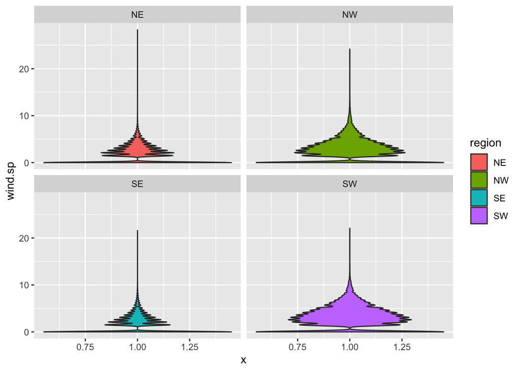

```r
windspplot <- met[!is.na(region)] %>% ggplot() +
  geom_violin(mapping=aes(x=1, y=wind.sp, fill=region)) + facet_wrap(~region)
windspplot
```

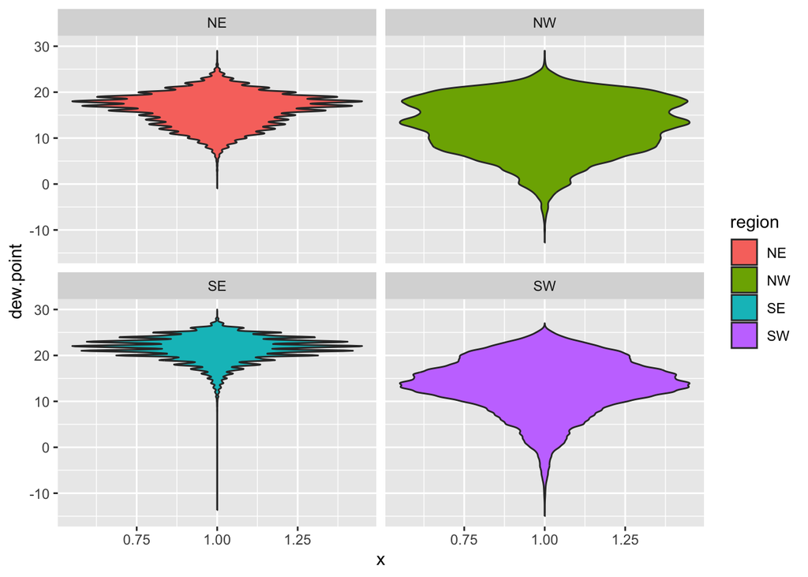

```r
dewptplot <- met[!is.na(region)] %>% ggplot() +
  geom_violin(mapping=aes(x=1, y=dew.point, fill=region)) + facet_wrap(~region)
dewptplot
```

Based on the graph we see there is a lot of variation in the distribution of the southwestern and northwestern region. Both these regions have more observations that appear as outliers. The southeastern and northeastern regions have some sparseness in their variability and specifically the northeast region has a smaller range than the other regions.

## Question 4

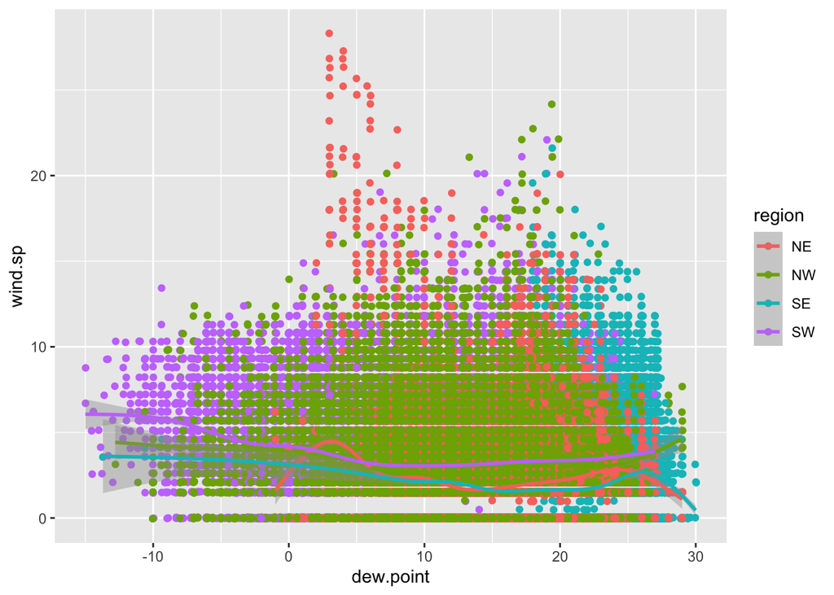

```r
p3 <- met[!is.na(region)] %>%
  ggplot() + geom_jitter(aes(x=dew.point,y=wind.sp, color = region)) + stat_smooth(aes(dew.point, wind.sp, color=region)) +  scale_linetype_manual(values = c("dashed","dotted","solid","longdash" ))
p3
```

In general the region with the highest average wind.sp based on dew point was the southwestern region. Genearlly the four regions have smooth curves that are fairly similar to one another. As we saw from the boxplots and now from these smooth curves the north eastern group had the highest minimum dew point of all the regions.

## Question 5

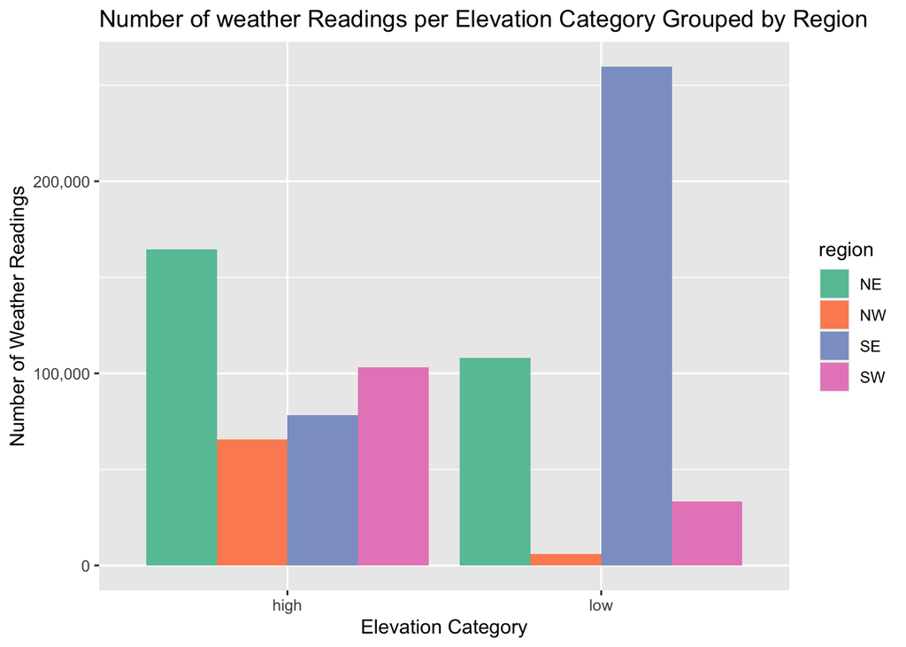

```r
library(scales)
p4 <- met[!is.na(region) & !is.na(elev_cat)] %>%
  ggplot() +  geom_bar(mapping = aes(x = elev_cat, fill = region), position = "dodge") + scale_fill_brewer(palette = "Set2") + xlab("Elevation Category") + ylab("Number of Weather Readings")
p4 + scale_y_continuous(labels = label_comma()) + labs(title="Number of weather Readings per Elevation Category Grouped by Region")
```

## Question 6

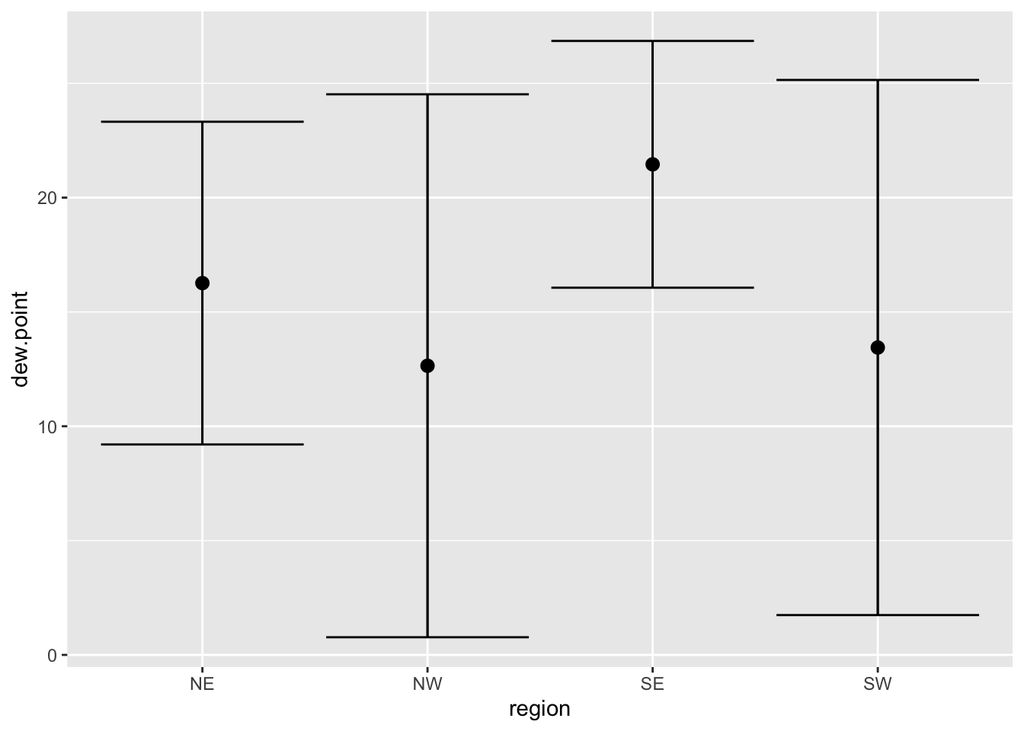

```r
p5 <- met[!is.na(region)] %>% ggplot() +
    stat_summary(mapping = aes(x = region, y = dew.point), fun.data = mean_sdl) +
      stat_summary(mapping = aes(x = region, y = dew.point), geom="errorbar", fun.data = mean_sdl)

p5
```

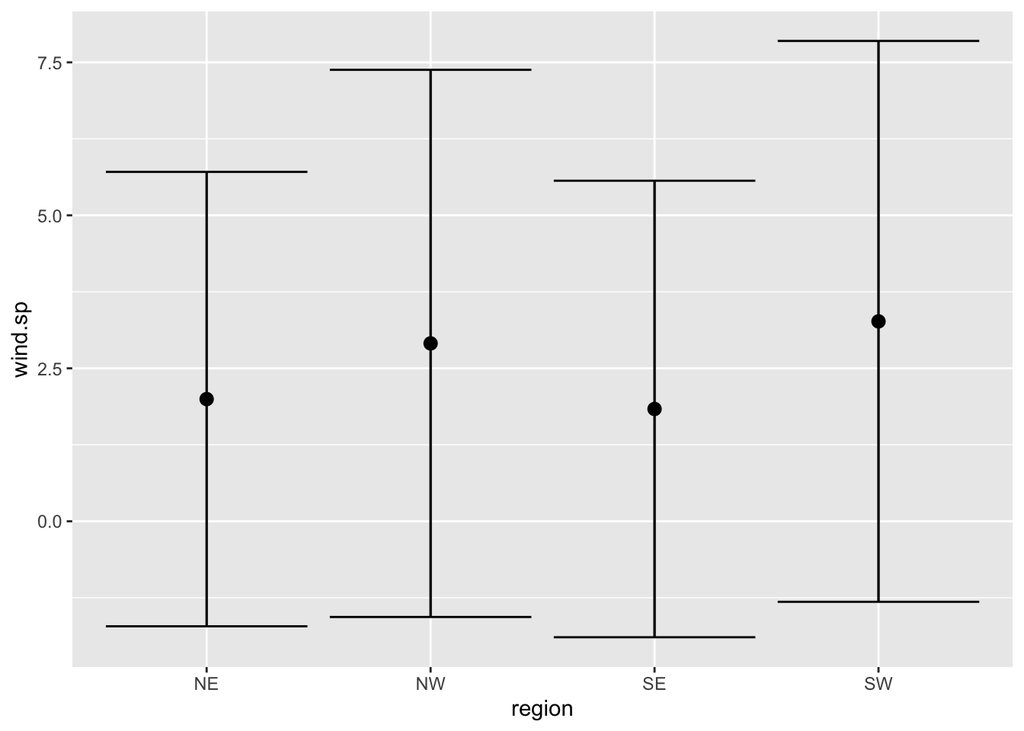

```r
p6 <- met[!is.na(region)] %>% ggplot() +
    stat_summary(mapping = aes(x = region, y = wind.sp), fun.data = mean_sdl) +
      stat_summary(mapping = aes(x = region, y = wind.sp), geom="errorbar", fun.data = mean_sdl)

p6
```

The mean dew point was highest in the southeast region at about 22 units per measure and lowest in the northwest region at approximately 12.5 units per measure. There was large variability among these readings. Variation of the mean was lowest in the Southeast region.

The mean wind speed was highest in the southwest region, at about 3.3 units per measure and the lowest in the southeast region at about 1.8 units per measure. Among all regions there was fairly high variability.

## Question 7

```r
library(leaflet)
met_avg2 <- met[,.(rh = mean(rh,na.rm=TRUE), lat = mean(lat), lon = mean(lon)),  by=c("USAFID")]
met_avg2 <- met_avg2[!is.na(rh)]
met_avg2 <- met_avg2[order(rh)]

# Generating a color palette
rh.pal <- colorNumeric(c('darkblue','goldenrod','red'), domain=met_avg2$rh)
rh.pal
```

[output not shown]

```r
rhmap <- leaflet(met_avg2) %>%
  # The looks of the Map
  addProviderTiles('CartoDB.Positron') %>%
  # Some circles
  addCircles(
    lat = ~lat, lng=~lon,
                                                  # HERE IS OUR PAL!
    label = ~paste0(round(rh,2), ' C'), color = ~ rh.pal(rh),
    opacity = 1, fillOpacity = 1, radius = 500
    ) %>%
  # And a pretty legend
  addLegend('bottomleft', pal=rh.pal, values=met_avg2$rh,
          title='Relative Humidity', opacity=1) %>%
  addMarkers(data=tail(met_avg2,10), lng=~lon, lat=~lat)
rhmap
```

[interactive chart not shown]

Based on our map the cities within the state of Florida had the highest relative humidity percentage. In general, a majority of the highest humidity cities are in the Southeast. Though two of the ten highest readings were in California, many of the lower relative humidity readings were in fact in California and other parts of the Southwest.

## Question 8

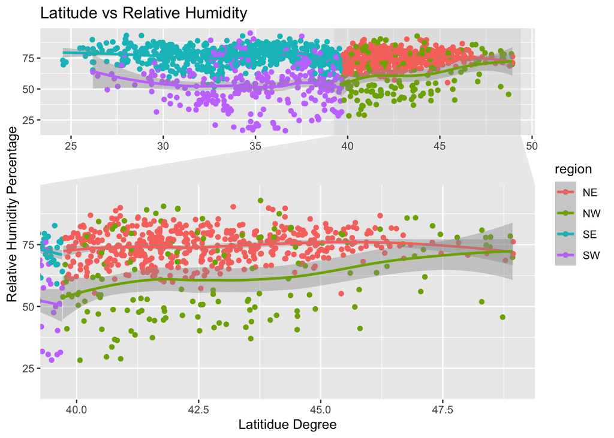

```r
devtools::install_github("thomasp85/ggforce")
library(ggforce)

met_avg3 <- met[,.(rh = mean(rh,na.rm=TRUE), lat = mean(lat), lon = mean(lon)),  by=c("USAFID","region")]
met_avg3 <- met_avg3[!is.na(rh) &!is.na(region)]

p7 <- ggplot(met_avg3, aes(lat, rh, color=region)) +
  geom_point() + geom_smooth(mapping=aes(lat,rh)) + xlab("Latitidue Degree") + ylab("Relative Humidity Percentage") + labs(title="Latitude vs Relative Humidity ") +
 facet_zoom(x = region == "NW")

p7
```

It is known by many that the humidity levels increase significantly the closer you are to the Earth’s equator and actually decreases the further north you travel. In an attempt to visually depict this relationship and test this association. Based on our plot we sort of have a tough time observing the hypothesized relationship stated previously. However, we do see a slight trend in that the relative humidity is generally higher on the east coast than on the west coast. Upon further research, this relationship does seem to be consistency with other knowledge.